# timeseries

Alexander Correa

10/22/2020

# Antecedentes

# Objetivo

# Análisis de los datos

En primer lugar, se importa el conjunto de datos

```r
library(ggfortify, quietly = T)
library(forecast, quietly = T)

setwd("~/R")

amzn <- read.csv("AMZN.csv")

head(amzn)
```

```
##         Date   Open   High    Low  Close Adj.Close   Volume
## 1 2010-01-04 136.25 136.61 133.14 133.90    133.90  7599900
## 2 2010-01-05 133.43 135.48 131.81 134.69    134.69  8851900
## 3 2010-01-06 134.60 134.73 131.65 132.25    132.25  7178800
## 4 2010-01-07 132.01 132.32 128.80 130.00    130.00 11030200
## 5 2010-01-08 130.56 133.68 129.03 133.52    133.52  9830500
## 6 2010-01-11 132.62 132.80 129.21 130.31    130.31  8779400
```

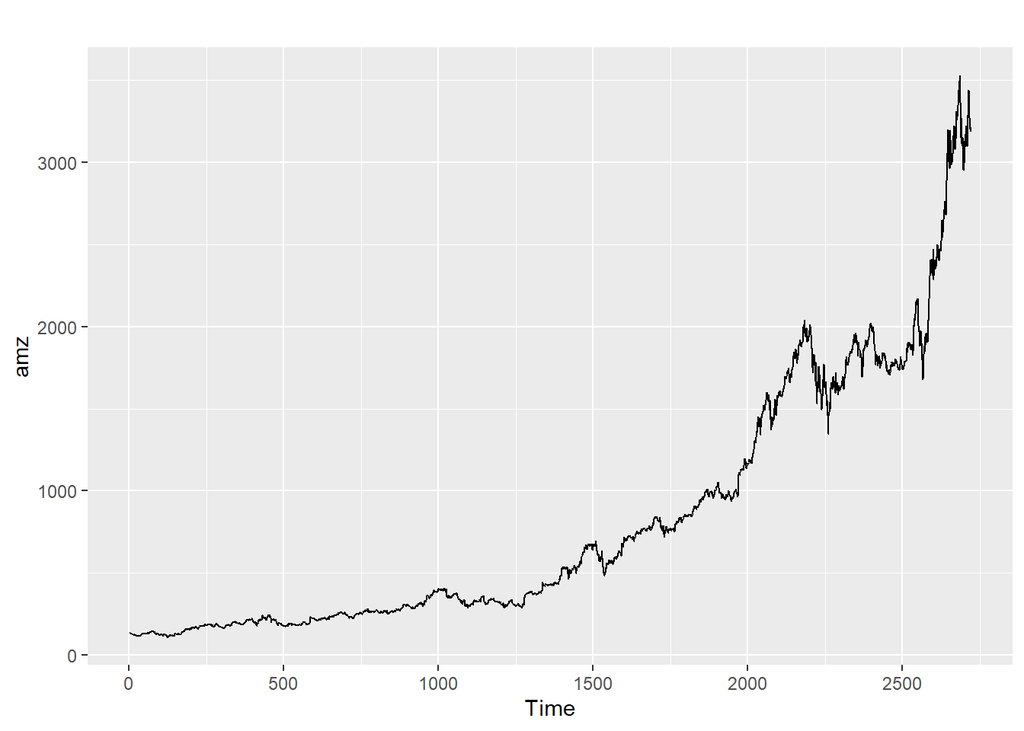

```r
N <- nrow(amzn)
amz <- ts(amzn$Adj.Close[1:N])
autoplot(amz)
```

El gráfico muestra que en términos generales, el precio de cierre ajustado de AMZN exhibe una tendencia al alza durante este período de tiempo. No obstante, no se observa un patrón obvio en las fluctuaciones de este activo. En otras palabras, no existe estacionalidad, sino una tendencia al alza. De igual forma, por lo que se aprecia en el gráfico, la varianza no es estable y parece aumentar del período 2000 en adelante. Por lo tanto, los datos originales se transforman a logaritmo para estabilizar la varianza.

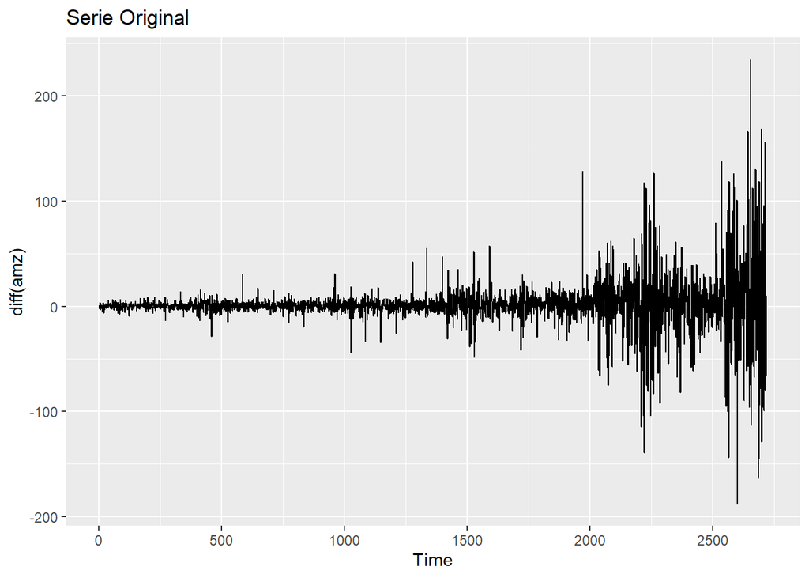

```r
autoplot(diff(amz), main = "Serie Original")
```

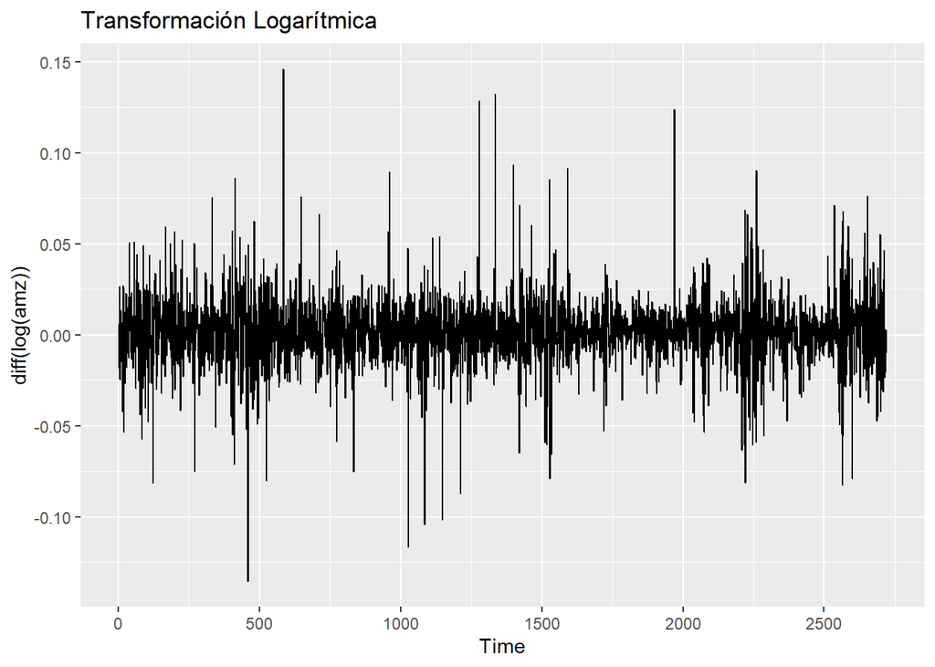

```r
autoplot(diff(log(amz)),main = "Transformación Logarítmica")
```

Se nota que la primera diferencia de la serie original presenta varianza creciente en la medida que el tiempo avanza. Por otro lado, la transformación logarítmica proporciona una varianza relativamente estable a lo largo del tiempo. Por lo tanto, se usa la transformación logarítmica de los datos originales.

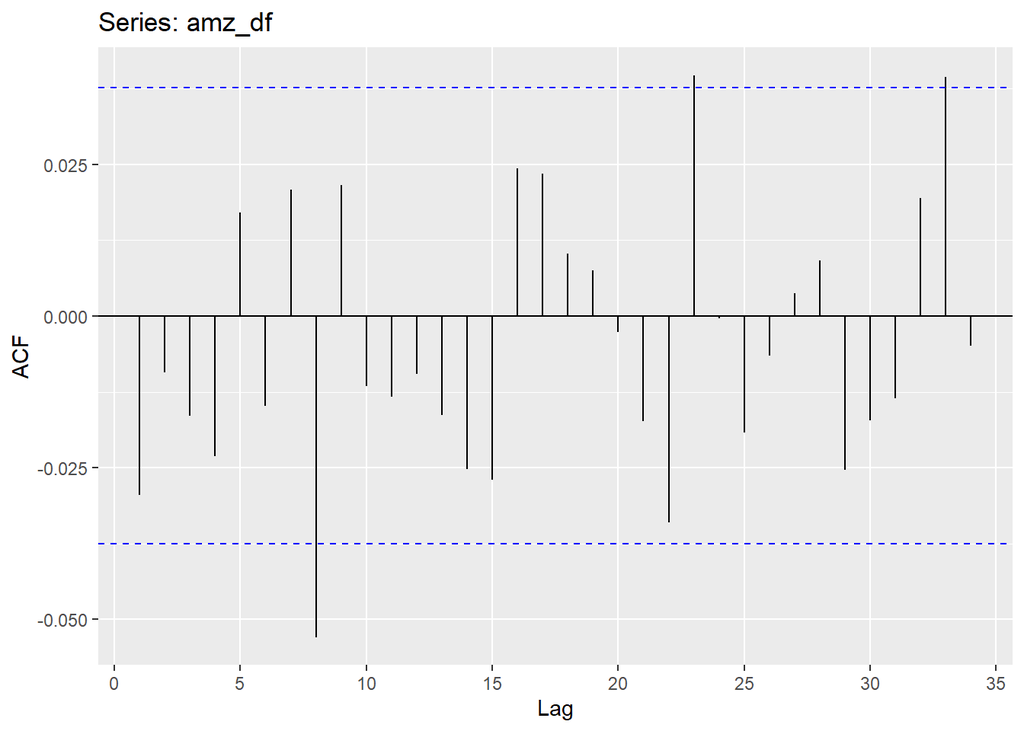

```r
amz_df <- diff(log(amz))
ggAcf(amz_df)
```

Las series de tiempo pueden ser descompuestas en tres componentes: tendencia, componente estacional y componente aleatorio, los cuales se denotan como $T_t$, $S_t$ y $R_t$ respectivamente, denotando la serie de tiempo original como $Y_t$, es posible escribir $Y_t$ como una función de los tres componentes:

$$Y_t = f(T_t, S_t, R_t)$$

Para la transformación logarítmica, la función $f$ toma la forma aditiva:

$$Y_t = T_t+S_t+R_t$$

El objetivo de identificar los diferentes componentes es separar el componente aleatorio de los otros componentes de la serie. Esto es, se quiere eliminar el ruido y aislar la señal. El siguiente gráfico muestra la descompsición de los datos de AMZN.

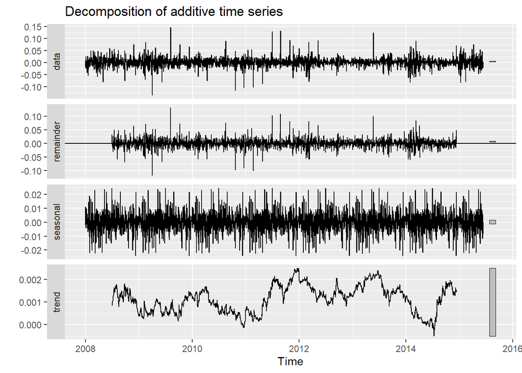

```r
amz_ts <- ts(amz_df,frequency = 365,start = 2010-01-01 )
amz_de <- decompose(amz_ts)
autoplot(amz_de)
```

Para estimar el modelo $ARMA(p,q)$ se deben seleccionar $p$ y $q$ utilizando el criterio AIC.

```r
amz_rand <- amz_de$random
aic_table <- function(data,P,Q){
  table <- matrix(NA,(P+1),(Q+1))
  for(p in 0:P) {
    for(q in 0:Q) {
       table[p+1,q+1] <- arima(data,order=c(p,0,q))$aic
    }
  }
  dimnames(table) <- list(paste("AR",0:P, sep=""),paste("MA",0:Q,sep=""))
  table
}

amz_aic_table <- aic_table(amz_rand, 4, 4)
```

```r
require(knitr)
kable(amz_aic_table, digits = 2)
```

|  | MA0 | MA1 | MA2 | MA3 | MA4 |
| --- | --- | --- | --- | --- | --- |
| AR0 | -12301.87 | -12299.87 | -12298.95 | -12299.27 | -12299.15 |
| AR1 | -12299.87 | -12297.87 | -12305.48 | -12304.31 | -12297.15 |
| AR2 | -12298.89 | -12306.63 | -12319.96 | -12317.78 | -12316.44 |
| AR3 | -12299.18 | -12305.21 | -12317.77 | -12316.60 | -12315.44 |
| AR4 | -12298.94 | -12296.94 | -12294.95 | -12292.96 | -12321.72 |

De la tabla AIC, se elige el modelo $ARMA(1,2)$ porque aunque existen otras opciones, tales como un $ARMA(4,4)$ o un $ARMA(2,2)$ que tienen menores valores AIC, la simplicidad también es un factor importante al momento de seleccionar $p$ y $q$.

```r
arma12 <- arima(amz_rand, order = c(1,0,2))
arma12
```

```
##
## Call:
## arima(x = amz_rand, order = c(1, 0, 2))
##
## Coefficients:
##          ar1      ma1      ma2  intercept
##       0.8927  -0.8912  -0.0315     -1e-04
## s.e.  0.1521   0.1534   0.0268      3e-04
##
## sigma^2 estimated as 0.0003136:  log likelihood = 6157.74,  aic = -12305.48
```

A continuación se realiza el diagnóstico de los errores del modelo:

# normalidad

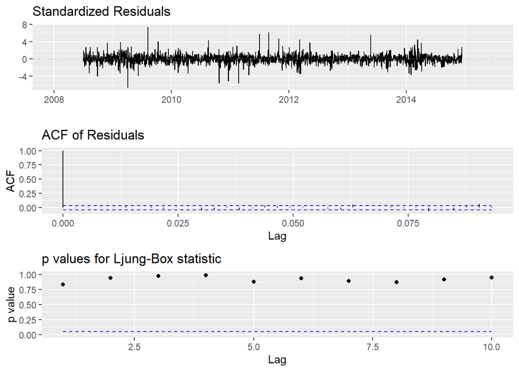

```r
ggtsdiag(arma12)
```

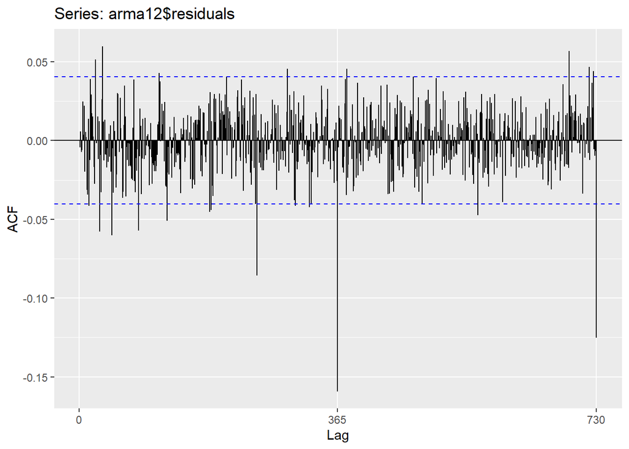

```r
ggAcf(arma12$residuals)
```

Aunque la ACF presenta niveles bajos de autocorrelación, algunos rezagos se salen del intervalo de confianza. Los errores exhiben clusters de volatilidad, por lo cual se debería pensar en un modelo más adecuado para este tipo de situaciones.

## Pronóstico

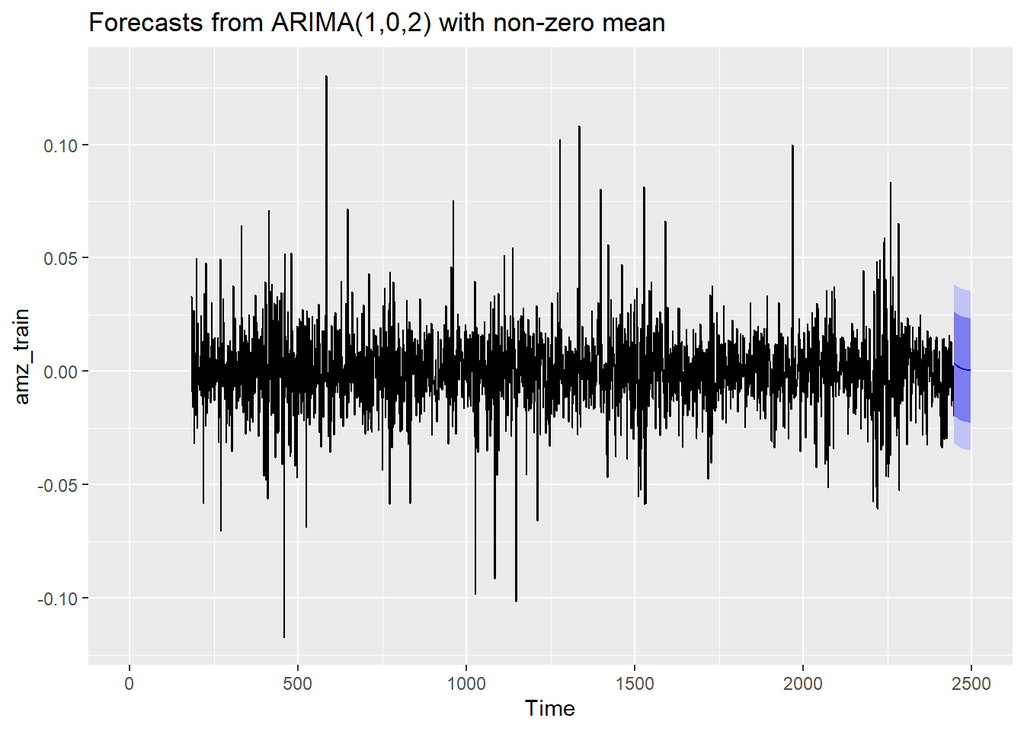

```r
amz_train <- amz_rand[1:((0.9)*length(amz_rand))]
amz_test <- amz_rand[(0.9*length(amz_rand)):length(amz_rand)]
train12 <- arima(amz_train, order = c(1,0,2))
pred <- predict(train12, n.ahead = (length(amz_rand)-(0.9*length(amz_rand))))$pred
forecast <- forecast(train12, h = 50)
autoplot(forecast)
```